# Balancing Time

```r
library(tidyverse)
library(car)
library(pander)

CAs <- read_csv("../Data/CAschools.csv")

cas <- CAs %>%
  filter(QualityTime < 168)
```

## Summary

#### Background

**How do high school students spend thier time?** To answer this question, I colleced data from [Census at School Random Sampler](https://ww2.amstat.org/censusatschool/Randomsampleconditions.cfm) and chose to get a random sample of 500 from California schools in 2018. I chose this because I’m from California and when I tried Idaho, it couldn’t quite give me 500 data points and I wanted to get as much data as possible.

*Note: I had to filter out a few points because they were impossibly high (spent 40,000 house of quality time in one week), so I filtered out any responses that had QualityTime over 168 (7 days a week * 24 hours in a day) hours.*

Below is the plot of my random sample with the least squares regression line. Time spent on media and technology (x-axis) includes watching TV, social media, texting, video games. Qualtiy time (y-axis) includes time spent with family, doing outdoor activities, and working.

```r
cas.lm <- lm(QualityTime ~ SpentTime, data = cas)
```

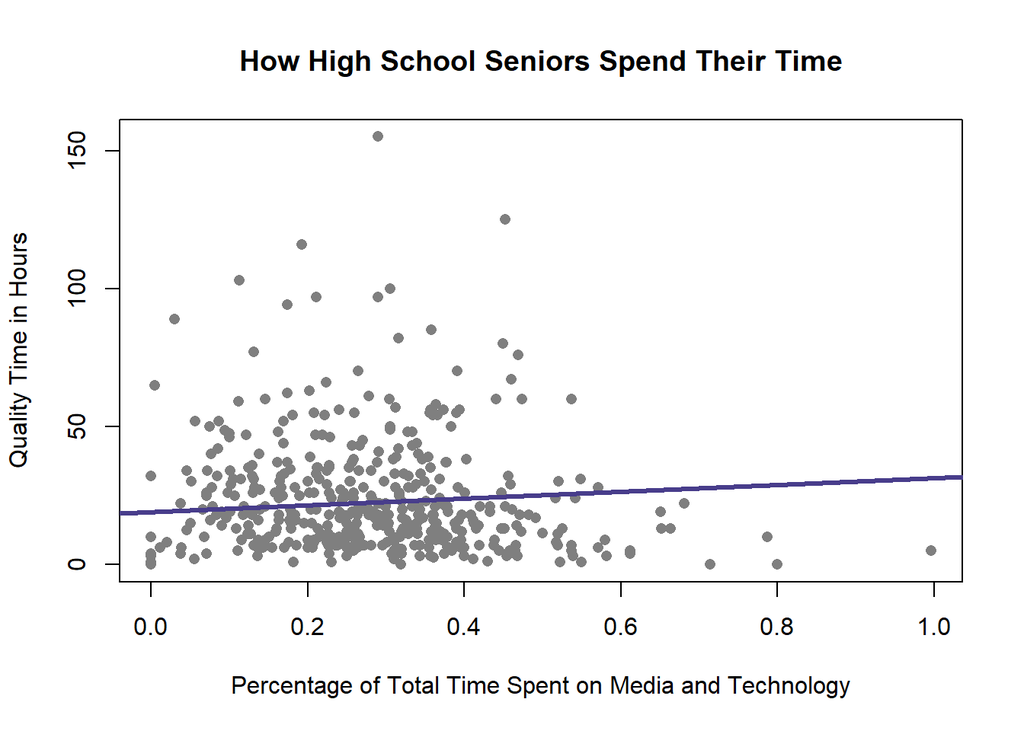

```r
plot(QualityTime ~ SpentTime, data = cas, pch = 16, col = "gray50", main = "How High School Seniors Spend Their Time", xlab = "Percentage of Total Time Spent on Media and Technology", ylab = "Quality Time in Hours")
abline(cas.lm, lwd = 3, col = "darkslateblue")
```

## Technical Details and Hypothesis

#### Hypothesis:

$$H_0: \beta_1 = 0$$

$$H_a: \beta_1 \ne 0$$

$$\alpha = .05$$

#### Summary of the regression:

```r
pander(summary(cas.lm))
```

|  | Estimate | Std. Error | t value | Pr(>\|t\|) |
| --- | --- | --- | --- | --- |
| **(Intercept)** | 18.96 | 1.81 | 10.48 | 2.478e-23 |
| **SpentTime** | 12.29 | 6.061 | 2.028 | 0.04305 |

Fitting linear model: QualityTime ~ SpentTime

| Observations | Residual Std. Error | $R^2$ | Adjusted $R^2$ |
| --- | --- | --- | --- |
| 498 | 21.22 | 0.008227 | 0.006227 |

#### Confidence Intervals

Confidence intervals at the 95% level show that when we take a sample of the same data (population) over and over, we will get estimates within these bounds 95% percent of the time.

```r
pander(confint(cas.lm))
```

|  | 2.5 % | 97.5 % |
| --- | --- | --- |
| **(Intercept)** | 15.4 | 22.52 |
| **SpentTime** | 0.3857 | 24.2 |

#### Mathematical model for the true line:

$$\underbrace{Y_i}_\text{Quality Time} = \overbrace{\beta_0 + \beta_1 \underbrace{X_i}_\text{Percent of Non-Quality Time}}^\text{Linear Relationship} + \epsilon_i \quad \text{where} \ \epsilon_i \sim N(0,\sigma^2)$$

#### Equation for the estimated line:

$$\hat{Y_i} = 18.96 + 12.29X_i$$

## Diagnostic Plots

These look a little weird, let’s look at them one at a time.

- **Residuals vs Fitted** - The left half looks okay, and then it just gets skewed from there. Linearity and constant variance are both somewhat questionable.
- **Normal QQ-Plot** - This one definitly looks off. Both ends are skewed (which is probably effected by the linearity of the first plot). Specifically, points 317 and 175 are way out of bounds in the top right-corner which is why they are labeled.
- **Residuals vs Order** - This one actually looks okay so we can assume the error terms are independent of each other.

```r
par(mfrow = c(1,3))
plot(cas.lm, which = 1)
qqPlot(cas.lm$residuals, main = "Normal QQ-plot", ylab = "Residuals")
```

```
## [1] 317 175
```

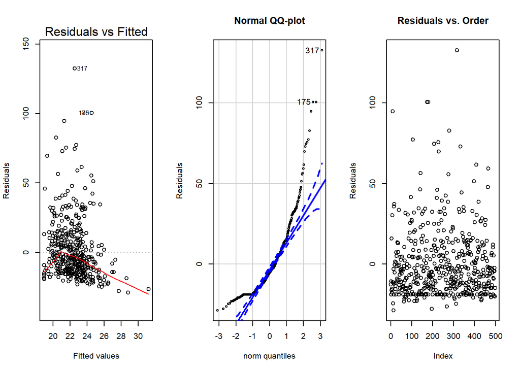

```r
plot(cas.lm$residuals, main = "Residuals vs. Order", ylab = "Residuals")
```